# Gapminder Data Analysis

## Exploratory Data Analysis and Visualization with Python

by [**Nosheen Altaf**](https://www.linkedin.com/in/nosheen-altaf-565158a/)

## The DATA:

The present data is extracted from [gapminder](https://www.gapminder.org/data/) ,the data frame includes six [variables](https://www.gapminder.org/data/documentation/) country, continent, year, lifeExp (life expectancy at birth), pop(total population), gdpPercap (per-capita GDP). Per-capita GDP (Gross domestic product) is given in units of international dollars, "a hypothetical unit of currency that has the same purchasing power parity that the U.S. dollar had in the United States at a given point in time"

## Project Overview

we will explore the data by creating visualizations, summary statistics, distribution analysis etc.

## Get the Data

```python
import pandas as pd
import numpy as np
import seaborn as sns
import matplotlib.pyplot as plt
from plotly.offline import download_plotlyjs, init_notebook_mode, plot, iplot
import cufflinks as cf
init_notebook_mode(connected=True)
cf.go_offline()
%matplotlib inline
```

```python
df=pd.read_csv('gapminder.csv')
```

## Data Investigation

Lets get familiar with our data by viewing it!

We will examine if the data is complete and if there is no null values, we will make sure that there is no inconsistency in different level of categorical variables, variable info ,variable type etc.

```python
df.head() #first 5 rows
```

|  | country | continent | year | lifeExp | pop | gdpPercap |
| --- | --- | --- | --- | --- | --- | --- |
| 0 | Afghanistan | Asia | 1952 | 28.801 | 8425333 | 779.445314 |
| 1 | Afghanistan | Asia | 1957 | 30.332 | 9240934 | 820.853030 |
| 2 | Afghanistan | Asia | 1962 | 31.997 | 10267083 | 853.100710 |
| 3 | Afghanistan | Asia | 1967 | 34.020 | 11537966 | 836.197138 |
| 4 | Afghanistan | Asia | 1972 | 36.088 | 13079460 | 739.981106 |

```python
df.tail() #last 5 rows
```

|  | country | continent | year | lifeExp | pop | gdpPercap |
| --- | --- | --- | --- | --- | --- | --- |
| 1699 | Zimbabwe | Africa | 1987 | 62.351 | 9216418 | 706.157306 |
| 1700 | Zimbabwe | Africa | 1992 | 60.377 | 10704340 | 693.420786 |
| 1701 | Zimbabwe | Africa | 1997 | 46.809 | 11404948 | 792.449960 |
| 1702 | Zimbabwe | Africa | 2002 | 39.989 | 11926563 | 672.038623 |
| 1703 | Zimbabwe | Africa | 2007 | 43.487 | 12311143 | 469.709298 |

```python
len(df) #total number of observations
```

```
1704
```

```python
df.isnull().sum() #to check null values
```

```
country      0
continent    0
year         0
lifeExp      0
pop          0
gdpPercap    0
dtype: int64
```

```python
df.info() # to get data structure info
```

```
<class 'pandas.core.frame.DataFrame'>
RangeIndex: 1704 entries, 0 to 1703
Data columns (total 6 columns):
country      1704 non-null object
continent    1704 non-null object
year         1704 non-null int64
lifeExp      1704 non-null float64
pop          1704 non-null int64
gdpPercap    1704 non-null float64
dtypes: float64(2), int64(2), object(2)
memory usage: 80.0+ KB
```

```python
df['continent'].unique() #to see if there is any inconsistency in continent's name
```

```
array(['Asia', 'Europe', 'Africa', 'Americas', 'Oceania'], dtype=object)
```

```python
df['country'].unique() #to see if there is any inconsistency in country's name
```

```
array(['Afghanistan', 'Albania', 'Algeria', 'Angola', 'Argentina',
       'Australia', 'Austria', 'Bahrain', 'Bangladesh', 'Belgium',
       'Benin', 'Bolivia', 'Bosnia and Herzegovina', 'Botswana', 'Brazil',
       'Bulgaria', 'Burkina Faso', 'Burundi', 'Cambodia', 'Cameroon',
       'Canada', 'Central African Republic', 'Chad', 'Chile', 'China',
       'Colombia', 'Comoros', 'Congo, Dem. Rep.', 'Congo, Rep.',
       'Costa Rica', "Cote d'Ivoire", 'Croatia', 'Cuba', 'Czech Republic',
       'Denmark', 'Djibouti', 'Dominican Republic', 'Ecuador', 'Egypt',
       'El Salvador', 'Equatorial Guinea', 'Eritrea', 'Ethiopia',
       'Finland', 'France', 'Gabon', 'Gambia', 'Germany', 'Ghana',
       'Greece', 'Guatemala', 'Guinea', 'Guinea-Bissau', 'Haiti',
       'Honduras', 'Hong Kong, China', 'Hungary', 'Iceland', 'India',
       'Indonesia', 'Iran', 'Iraq', 'Ireland', 'Israel', 'Italy',
       'Jamaica', 'Japan', 'Jordan', 'Kenya', 'Korea, Dem. Rep.',
       'Korea, Rep.', 'Kuwait', 'Lebanon', 'Lesotho', 'Liberia', 'Libya',
       'Madagascar', 'Malawi', 'Malaysia', 'Mali', 'Mauritania',
       'Mauritius', 'Mexico', 'Mongolia', 'Montenegro', 'Morocco',
       'Mozambique', 'Myanmar', 'Namibia', 'Nepal', 'Netherlands',
       'New Zealand', 'Nicaragua', 'Niger', 'Nigeria', 'Norway', 'Oman',
       'Pakistan', 'Panama', 'Paraguay', 'Peru', 'Philippines', 'Poland',
       'Portugal', 'Puerto Rico', 'Reunion', 'Romania', 'Rwanda',
       'Sao Tome and Principe', 'Saudi Arabia', 'Senegal', 'Serbia',
       'Sierra Leone', 'Singapore', 'Slovak Republic', 'Slovenia',
       'Somalia', 'South Africa', 'Spain', 'Sri Lanka', 'Sudan',
       'Swaziland', 'Sweden', 'Switzerland', 'Syria', 'Taiwan',
       'Tanzania', 'Thailand', 'Togo', 'Trinidad and Tobago', 'Tunisia',
       'Turkey', 'Uganda', 'United Kingdom', 'United States', 'Uruguay',
       'Venezuela', 'Vietnam', 'West Bank and Gaza', 'Yemen, Rep.',
       'Zambia', 'Zimbabwe'], dtype=object)
```

## Data Visualization

Lets explore the data by creating some visualizations

### Per Capita GDP Trend Over Years

```python
pd.pivot_table(data=df,values='gdpPercap',
               index='year',
               columns='continent',
               aggfunc='mean').iplot(title="Continent's Per Capita GDP Trend over Time",
                                     yTitle='gdpPercap',
                                     xTitle='Years',width=4,labels=True)
```

[interactive chart not shown]

### Summary Statistics of Per Capita GDP by Year by Continent

```python
df[['gdpPercap','year','continent']].groupby(['continent','year']).describe().round(2).head(12)
```

| continent | year | gdpPercap count | gdpPercap mean | gdpPercap std | gdpPercap min | gdpPercap 25% | gdpPercap 50% | gdpPercap 75% | gdpPercap max |
| --- | --- | --- | --- | --- | --- | --- | --- | --- | --- |
| Africa | 1952 | 52.0 | 1252.57 | 982.95 | 298.85 | 534.99 | 987.03 | 1454.89 | 4725.30 |
|  | 1957 | 52.0 | 1385.24 | 1134.51 | 336.00 | 606.95 | 1024.02 | 1573.04 | 5487.10 |
|  | 1962 | 52.0 | 1598.08 | 1461.84 | 355.20 | 673.33 | 1133.78 | 1702.22 | 6757.03 |
|  | 1967 | 52.0 | 2050.36 | 2847.72 | 412.98 | 779.82 | 1210.38 | 1890.11 | 18772.75 |
|  | 1972 | 52.0 | 2339.62 | 3286.85 | 464.10 | 815.92 | 1443.37 | 2292.26 | 21011.50 |
|  | 1977 | 52.0 | 2585.94 | 4142.40 | 502.32 | 805.61 | 1399.64 | 2841.28 | 21951.21 |
|  | 1982 | 52.0 | 2481.59 | 3242.63 | 462.21 | 828.66 | 1323.73 | 2787.58 | 17364.28 |
|  | 1987 | 52.0 | 2282.67 | 2566.53 | 389.88 | 764.60 | 1219.59 | 2786.31 | 11864.41 |
|  | 1992 | 52.0 | 2281.81 | 2644.08 | 410.90 | 743.91 | 1161.63 | 2707.90 | 13522.16 |
|  | 1997 | 52.0 | 2378.76 | 2820.73 | 312.19 | 791.90 | 1179.88 | 2856.39 | 14722.84 |
|  | 2002 | 52.0 | 2599.39 | 2972.65 | 241.17 | 780.58 | 1215.68 | 3314.89 | 12521.71 |
|  | 2007 | 52.0 | 3089.03 | 3618.16 | 277.55 | 862.95 | 1452.27 | 3993.50 | 13206.48 |

### Life Expectancy Trend Over Years

```python
pd.pivot_table(data=df,values='lifeExp',
               index='year',
               columns='continent',
               aggfunc='mean').iplot(title="Continent's life Expectancy Trend over Time",
                                     yTitle='lifeExp',
                                     xTitle='Years',width=3,labels=True)
```

[interactive chart not shown]

### Summary Statistics of Life Expectancy by Year by Continent

```python
df[['lifeExp','year','continent']].groupby(['continent','year']).describe().round(2).head(12)
```

| continent | year | lifeExp count | lifeExp mean | lifeExp std | lifeExp min | lifeExp 25% | lifeExp 50% | lifeExp 75% | lifeExp max |
| --- | --- | --- | --- | --- | --- | --- | --- | --- | --- |
| Africa | 1952 | 52.0 | 39.14 | 5.15 | 30.00 | 35.81 | 38.83 | 42.12 | 52.72 |
|  | 1957 | 52.0 | 41.27 | 5.62 | 31.57 | 37.43 | 40.59 | 44.85 | 58.09 |
|  | 1962 | 52.0 | 43.32 | 5.88 | 32.77 | 39.48 | 42.63 | 47.76 | 60.25 |
|  | 1967 | 52.0 | 45.33 | 6.08 | 34.11 | 41.37 | 44.70 | 49.53 | 61.56 |
|  | 1972 | 52.0 | 47.45 | 6.42 | 35.40 | 43.30 | 47.03 | 51.55 | 64.27 |
|  | 1977 | 52.0 | 49.58 | 6.81 | 36.79 | 44.51 | 49.27 | 53.87 | 67.06 |
|  | 1982 | 52.0 | 51.59 | 7.38 | 38.44 | 45.63 | 50.76 | 56.60 | 69.89 |
|  | 1987 | 52.0 | 53.34 | 7.86 | 39.91 | 46.84 | 51.64 | 59.45 | 71.91 |
|  | 1992 | 52.0 | 53.63 | 9.46 | 23.60 | 47.95 | 52.43 | 59.86 | 73.61 |
|  | 1997 | 52.0 | 53.60 | 9.10 | 36.09 | 47.30 | 52.76 | 59.23 | 74.77 |
|  | 2002 | 52.0 | 53.33 | 9.59 | 39.19 | 45.83 | 51.24 | 57.68 | 75.74 |
|  | 2007 | 52.0 | 54.81 | 9.63 | 39.61 | 47.83 | 52.93 | 59.44 | 76.44 |

### Population Growth Trend Over Years

```python
pd.pivot_table(data=df,values='pop',
               index='year',
               columns='continent',
               aggfunc='sum').iplot(title="Continent's Population Growth over Time",
                                     yTitle='pop',
                                     xTitle='Years',width=3,labels=True)
```

[interactive chart not shown]

### Summary Statistics of Population Growth by Year by Continent

```python
df[['pop','year','continent']].groupby(['continent','year']).agg({'pop':['count','sum','mean','min','max','std']}).round(2).head(12)
```

| continent | year | pop count | pop sum | pop mean | pop min | pop max | pop std |
| --- | --- | --- | --- | --- | --- | --- | --- |
| Africa | 1952 | 52 | 237640501 | 4570009.63 | 60011 | 33119096 | 6317449.64 |
|  | 1957 | 52 | 264837738 | 5093033.42 | 61325 | 37173340 | 7076041.88 |
|  | 1962 | 52 | 296516865 | 5702247.40 | 65345 | 41871351 | 7957544.74 |
|  | 1967 | 52 | 335289489 | 6447874.79 | 70787 | 47287752 | 8985504.94 |
|  | 1972 | 52 | 379879541 | 7305375.79 | 76595 | 53740085 | 10130832.61 |
|  | 1977 | 52 | 433061021 | 8328096.56 | 86796 | 62209173 | 11585183.92 |
|  | 1982 | 52 | 499348587 | 9602857.44 | 98593 | 73039376 | 13456243.44 |
|  | 1987 | 52 | 574834110 | 11054502.12 | 110812 | 81551520 | 15277483.96 |
|  | 1992 | 52 | 659081517 | 12674644.56 | 125911 | 93364244 | 17562719.28 |
|  | 1997 | 52 | 743832984 | 14304480.46 | 145608 | 106207839 | 19873013.49 |
|  | 2002 | 52 | 833723916 | 16033152.23 | 170372 | 119901274 | 22302996.90 |
|  | 2007 | 52 | 929539692 | 17875763.31 | 199579 | 135031164 | 24917726.17 |

### Countries GDP Per Capita Distribution for Year 2007

```python
pd.pivot_table(data=df.query("year==2007"),
               values='gdpPercap',
               index='country',
               columns='continent').iplot(kind='box',
                                          title="2007 Countries gdpPercap Distribution within Continents",
                                          yTitle='gdpPercap',width=2,labels=True)
```

[interactive chart not shown]

```python
import plotly.express as px
```

```python
dfx = px.data.gapminder().query("year==2007")
px.choropleth(dfx, locations="iso_alpha",
             color="gdpPercap",
             hover_name="country",
             title='Countries by GDP Per Capita',
             color_continuous_scale=px.colors.sequential.Plasma)
```

[interactive chart not shown]

### Countries Life Expectancy Distribution for Year 2007

```python
pd.pivot_table(data=df.query("year==2007"),
               values='lifeExp',
               index='country',
               columns='continent').iplot(kind='box',
                                         title="2007 Countries LifeExp Distribution within Continents",
                                         yTitle='lifExp',width=2,labels=True)
```

[interactive chart not shown]

```python
px.choropleth(dfx, locations="iso_alpha",
             color="lifeExp",
             hover_name="country",
             title='Countries by Life Expectancy',
             color_continuous_scale=px.colors.sequential.Plasma)
```

[interactive chart not shown]

### Countries Population Map for Year 2007

```python
px.choropleth(dfx, locations="iso_alpha",
             color="pop",
             hover_name="country",
             title='Countries by Population',
             color_continuous_scale=px.colors.sequential.Plasma)
```

[interactive chart not shown]

### Countries Life Expectancy vs. GDP Per Capita vs. Population for Year 2007

```python
fig = px.scatter(df.query("year==2007"),
                 x="gdpPercap",
                 y="lifeExp",
                 size="pop",
                 color="continent",
                 hover_name="country",
                 log_x=True,
                 size_max=60,
                 title='Life Expectancy vs. GDP Per Capita vs. Pop')
fig.show()
```

[interactive chart not shown]

Size of each bubble is directly proportional to its country population

## Top 10 Countries with highest Life Expectancy for Year 2007

```python
df.query("year==2007").sort_values('lifeExp',ascending=False).head(10)
```

|  | country | continent | year | lifeExp | pop | gdpPercap |
| --- | --- | --- | --- | --- | --- | --- |
| 803 | Japan | Asia | 2007 | 82.603 | 127467972 | 31656.06806 |
| 671 | Hong Kong, China | Asia | 2007 | 82.208 | 6980412 | 39724.97867 |
| 695 | Iceland | Europe | 2007 | 81.757 | 301931 | 36180.78919 |
| 1487 | Switzerland | Europe | 2007 | 81.701 | 7554661 | 37506.41907 |
| 71 | Australia | Oceania | 2007 | 81.235 | 20434176 | 34435.36744 |
| 1427 | Spain | Europe | 2007 | 80.941 | 40448191 | 28821.06370 |
| 1475 | Sweden | Europe | 2007 | 80.884 | 9031088 | 33859.74835 |
| 767 | Israel | Asia | 2007 | 80.745 | 6426679 | 25523.27710 |
| 539 | France | Europe | 2007 | 80.657 | 61083916 | 30470.01670 |
| 251 | Canada | Americas | 2007 | 80.653 | 33390141 | 36319.23501 |

```python
pd.pivot_table( data=df,
               values='lifeExp',
               index='country',
               columns='year').sort_values(2007,
                                           ascending=False).iloc[:10,:].transpose().iplot(
    title="Top 10 Countries Life Expectancy over Years")
```

[interactive chart not shown]

## Top 10 Countries with highest GDP Per-Capita for Year 2007

```python
df.query("year==2007").sort_values('gdpPercap',ascending=False).head(10)
```

|  | country | continent | year | lifeExp | pop | gdpPercap |
| --- | --- | --- | --- | --- | --- | --- |
| 1151 | Norway | Europe | 2007 | 80.196 | 4627926 | 49357.19017 |
| 863 | Kuwait | Asia | 2007 | 77.588 | 2505559 | 47306.98978 |
| 1367 | Singapore | Asia | 2007 | 79.972 | 4553009 | 47143.17964 |
| 1619 | United States | Americas | 2007 | 78.242 | 301139947 | 42951.65309 |
| 755 | Ireland | Europe | 2007 | 78.885 | 4109086 | 40675.99635 |
| 671 | Hong Kong, China | Asia | 2007 | 82.208 | 6980412 | 39724.97867 |
| 1487 | Switzerland | Europe | 2007 | 81.701 | 7554661 | 37506.41907 |
| 1091 | Netherlands | Europe | 2007 | 79.762 | 16570613 | 36797.93332 |
| 251 | Canada | Americas | 2007 | 80.653 | 33390141 | 36319.23501 |
| 695 | Iceland | Europe | 2007 | 81.757 | 301931 | 36180.78919 |

```python
pd.pivot_table( data=df,
               values='gdpPercap',
               index='country',
               columns='year').sort_values(2007,
                                           ascending=False).iloc[:10,:].transpose().iplot(
    title="Top 10 Countries GDP Per Capita over Years")
```

[interactive chart not shown]

## Top 10 Countries with highest Population for Year 2007

```python
df.query("year==2007").sort_values('pop',ascending=False).head(10)
```

|  | country | continent | year | lifeExp | pop | gdpPercap |
| --- | --- | --- | --- | --- | --- | --- |
| 299 | China | Asia | 2007 | 72.961 | 1318683096 | 4959.114854 |
| 707 | India | Asia | 2007 | 64.698 | 1110396331 | 2452.210407 |
| 1619 | United States | Americas | 2007 | 78.242 | 301139947 | 42951.653090 |
| 719 | Indonesia | Asia | 2007 | 70.650 | 223547000 | 3540.651564 |
| 179 | Brazil | Americas | 2007 | 72.390 | 190010647 | 9065.800825 |
| 1175 | Pakistan | Asia | 2007 | 65.483 | 169270617 | 2605.947580 |
| 107 | Bangladesh | Asia | 2007 | 64.062 | 150448339 | 1391.253792 |
| 1139 | Nigeria | Africa | 2007 | 46.859 | 135031164 | 2013.977305 |
| 803 | Japan | Asia | 2007 | 82.603 | 127467972 | 31656.068060 |
| 995 | Mexico | Americas | 2007 | 76.195 | 108700891 | 11977.574960 |

```python
pd.pivot_table( data=df,
               values='pop',
               index='country',
               columns='year').sort_values(2007,
                                           ascending=False).iloc[:10,:].transpose().iplot(
    title="Top 10 Countries Population Growth over Years")
```

[interactive chart not shown]

## Correlation Analysis

Lets explore if there is any correlation between GDP Per-Capita and Life Expectancy

### Pattern Analysis between GDP Per Capita and Life Expectancy

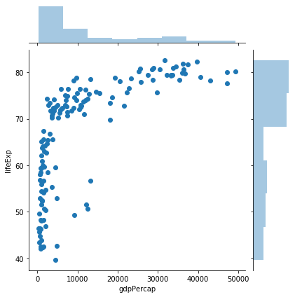

```python
sns.jointplot(x='gdpPercap',y='lifeExp',data=df.query("year==2007"),kind='scatter');
```

we can see that high there is some positive pattern between both variables, we can further confirm this by calculating correlation matrix

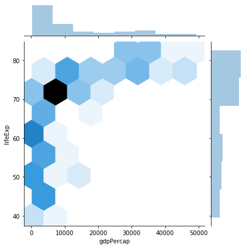

```python
sns.jointplot(x='gdpPercap',y='lifeExp',data=df.query("year==2007"),kind='hex');
```

Another way to visualize the central tendency of both variables

### Correlation Analysis between GDP Per Capita and Life Expectancy

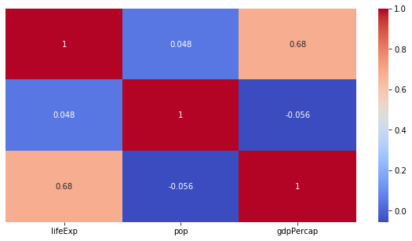

```python
from pylab import rcParams
rcParams['figure.figsize']=10,5
sns.heatmap(df.query("year==2007").drop(['year'],axis=1).corr(),
            cmap='coolwarm',
            annot=True,
            xticklabels=1, yticklabels=False);
```

There is a positive r=0.68 correlation between life Expectancy and GDP Per-capita

Lastly,lets review distribution analysis of Life Expectancy and GDP Per Capita

### Countries Life Expectancy Distribution over Years

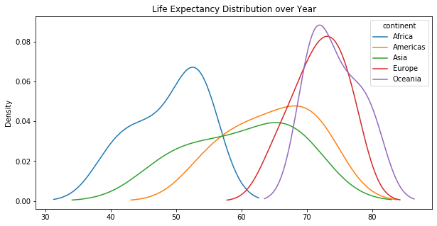

```python
pd.pivot_table(data=df,
               values='lifeExp',
               index='year',
               columns='continent',
               aggfunc='mean').plot.density(figsize=(10,5),
                                            title='Life Expectancy Distribution over Year')
plt.show()
```

### Countries Per Capita GDP Distribution over Years

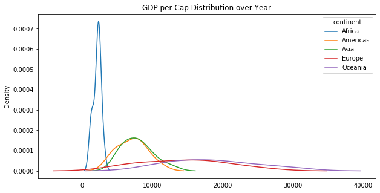

```python
pd.pivot_table(data=df,
               values='gdpPercap',
               index='year',
               columns='continent',
               aggfunc='mean').plot.density(figsize=(10,5),
                                            title='GDP per Cap Distribution over Year')
plt.show()
```